# Shoe brand observation visual data story

## About the data collection

I wanted to observe shoe trends. Coming from a high school with strict rules when it came to uniforms, shoes were also included in this. I had only worn regular black shoes to school for 5 years. So, as I became a university student, I noticed a lot of students wearing different shoe brands and shoe types, which also reflected in places outside of the university. The focus of my data collection was shoe trends. Throughout the week, I logged more and more observations using my Google Form.

## How unique are the shoe brands?

Throughout the week, I went to a couple of places, such as the university, shopping malls, and parks. When I see a group of people, I would note how many unique shoe brands I observe and where I make the observation at that time. So, I made a visualisation based on that data.

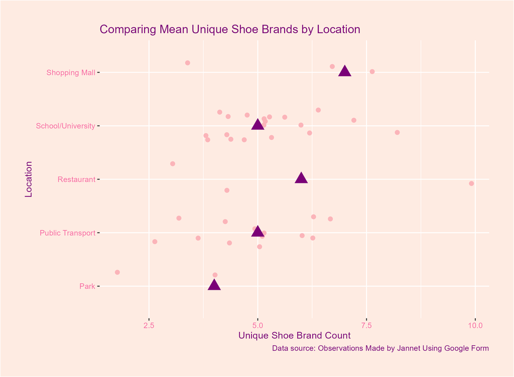

Title: Comparing Mean Unique Shoe Brands by Location, X axis: Unique Shoe Brand Count, Y axis: Location, Plot type: dot plot with mean pointer

I made sure to add a mean pointer so that I could tell what was the mean unique shoe brand count at that specific location.

## When have I made the observations?

I mostly made data collections during the day, because I would go out more. I could tell there were some times which are consistent, such as when my lectures were and when I took the bus each day. This made it so that I could easily plot it in a bar chart and see which hour of the day I would make the most observations.

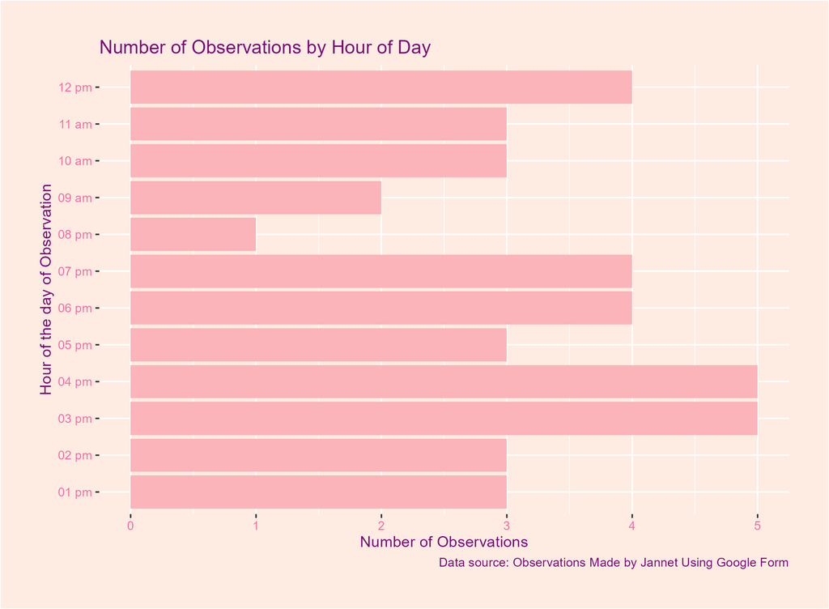

Title: Number of Observations by Hour of Day, X axis: Number of Observations, Y axis: Hour of the Day of Observation, Plot type: bar chart

I wanted to add an image onto my plot using the cuttingshapes package. So, I went to the pexels website and found an image that was relevant to my data, which was a picture of a Nike shoe. The shoe was similar to one I had observed when collecting data.

[figure not shown]

Same bar chart but with picture of Nike shoe on grass as the fill of the bars.

## Trend in brand name character count?

When it came to shoe brand names, I wondered if out of the shoe brands I had observed, how many of them had the same number of characters. So, I made a graph which showed this.

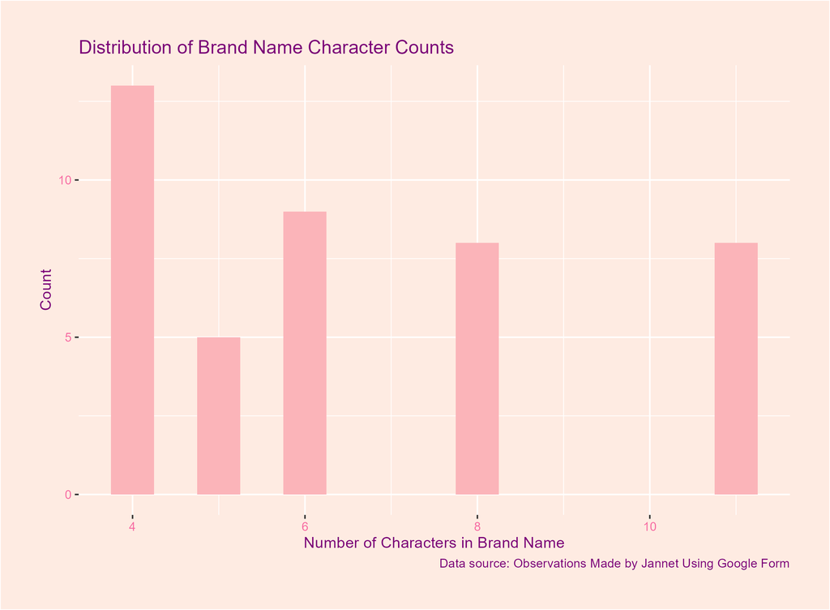

Title: Distribution of Brand Name Character Counts, X axis: Number of Characters in Brand Name, Y axis: Count, Plot type: Histogram

## GIF using magick package!

Using magick, I simply created a gif from all of the plots I have made for this visual data story.

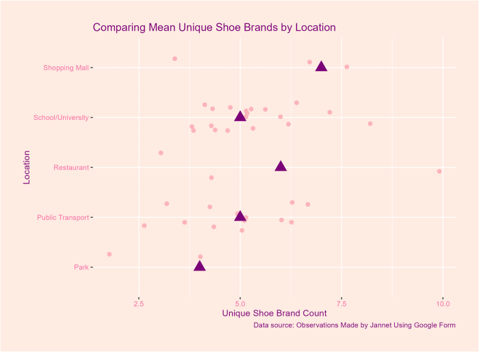

GIF showing all the charts